# STOR 455 Homework 4

**SETUP**

```r
library(readr)
library(mosaic)
library(Stat2Data)
library(car)
library(dplyr)
library(plyr)
```

```r
DistanceHome = read_csv("/Users/reidbrown/Documents/Senior/Spring 2020/STOR 455/Class Example Data/DistanceHome.csv")
Domestic = subset(DistanceHome, Distance <250)
source("/Users/reidbrown/Documents/Senior/Spring 2020/STOR 455/Class Scripts/anova455.R")
```

```r
UsedCars = read_csv("/Users/reidbrown/Documents/Senior/Spring 2020/STOR 455/Class Example Data/UsedCars.csv")
head(UsedCars)
```

| Id | Price | Year | Mileage | City | State | Vin | Make | Model |
| --- | --- | --- | --- | --- | --- | --- | --- | --- |
| 1 | 16472 | 2015 | 18681 | Jefferson City | MO | KL4CJBSBXFB267643 | Buick | EncoreConvenience |
| 2 | 15749 | 2015 | 27592 | Highland | IN | KL4CJASB5FB245057 | Buick | EncoreFWD |
| 3 | 16998 | 2015 | 13650 | Boone | NC | KL4CJCSB0FB264921 | Buick | EncoreLeather |
| 4 | 15777 | 2015 | 25195 | New Orleans | LA | KL4CJASB4FB217542 | Buick | EncoreFWD |
| 5 | 16784 | 2015 | 22800 | Las Vegas | NV | KL4CJBSB3FB166881 | Buick | EncoreConvenience |
| 6 | 17020 | 2016 | 16877 | Grand Island | NY | KL4CJASB7GB536760 | Buick | EncoreFWD |

```r
#make freq. table of all the models in the UsedCars dataset
cars = as.data.frame(table(UsedCars$Model))
head(cars)
```

|  | Var1 | Freq |
| --- | --- | --- |
| 1 | 1 | 437 |
| 2 | 124 | 56 |
| 3 | 1500 | 1 |
| 4 | 15002WD | 296 |
| 5 | 15004WD | 647 |
| 6 | 1500Big | 749 |

```r
#renaming columns
names(cars)[1] = "Model"
names(cars)[2] = "Count"
head(cars)
```

|  | Model | Count |
| --- | --- | --- |
| 1 | 1 | 437 |
| 2 | 124 | 56 |
| 3 | 1500 | 1 |
| 4 | 15002WD | 296 |
| 5 | 15004WD | 647 |
| 6 | 1500Big | 749 |

```r
cars2 = subset(cars, Count>=2500)
cars2
```

|  | Model | Count |
| --- | --- | --- |
| 29 | 200Limited | 4299 |
| 45 | 3 | 11131 |
| 103 | 5 | 5348 |
| 217 | AcadiaAWD | 3511 |
| 218 | AcadiaFWD | 4080 |
| 230 | Accord | 14946 |
| 249 | Altima2.5 | 15735 |
| 253 | Altima4dr | 2950 |
| 367 | C-ClassC300 | 3307 |
| 412 | CamaroCoupe | 5729 |

[output cut: 76 more lines]

Don’t choose CamrySE

```r
set.seed(11111)
MyCars = sample_n(subset(UsedCars, Model =="Accord"), 200)
range(MyCars$Year)
```

```
## [1] 2002 2017
```

```r
MyCars$Age = 2017 - MyCars$Year
#head(MyCars)
```

**MODEL #3: Polynomial models**

*Part A*

```r
#Fit a quadratic model using Age to predict Price and examine the residuals. Give the prediction equation and show a scatterplot of the data with the quadratic fit drawn on it.

model3a=lm(Price~poly(Age,degree=2, raw=TRUE), data=MyCars)
summary(model3a)
```

```
##
## Call:
## lm(formula = Price ~ poly(Age, degree = 2, raw = TRUE), data = MyCars)
##
## Residuals:
##     Min      1Q  Median      3Q     Max
## -5027.1 -1530.7  -456.2  1333.8  9237.6
##
## Coefficients:
##                                    Estimate Std. Error t value Pr(>|t|)
## (Intercept)                        23193.01     392.35  59.113  < 2e-16
## poly(Age, degree = 2, raw = TRUE)1 -2522.29     165.08 -15.280  < 2e-16
## poly(Age, degree = 2, raw = TRUE)2    91.67      12.95   7.078 2.51e-11
##
## (Intercept)                        ***
## poly(Age, degree = 2, raw = TRUE)1 ***
## poly(Age, degree = 2, raw = TRUE)2 ***
## ---
## Signif. codes:  0 '***' 0.001 '**' 0.01 '*' 0.05 '.' 0.1 ' ' 1
##
## Residual standard error: 2380 on 197 degrees of freedom
## Multiple R-squared:  0.7959, Adjusted R-squared:  0.7938
## F-statistic:   384 on 2 and 197 DF,  p-value: < 2.2e-16
```

```r
#Pulls output from summary table for curve.
b0.model3a = summary(model3a)$coefficient[1,1]
b1.model3a = summary(model3a)$coefficient[2,1]
b2.model3a = summary(model3a)$coefficient[3,1]

plot(Price~Age,main="Quadratic Model",data=MyCars)
curve(b0.model3a+b1.model3a*x+b2.model3a*x^2,add=TRUE)
```

[output not shown]

Prediction Equation is: Price = 91.67(Age^2) -2522.29(Age) + 23193.01

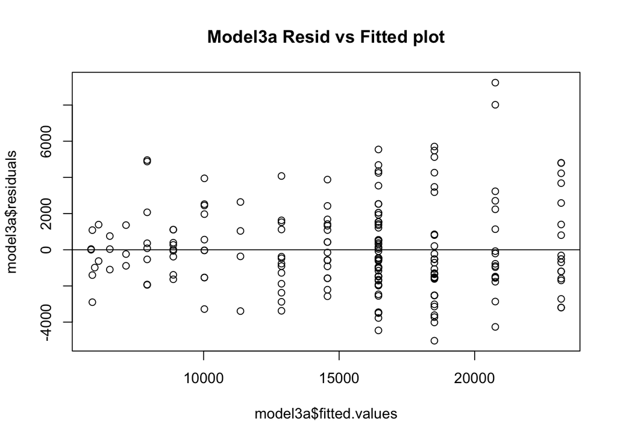

```r
plot(model3a$residuals~model3a$fitted.values, main="Model3a Resid vs Fitted plot")
abline(0,0)
```

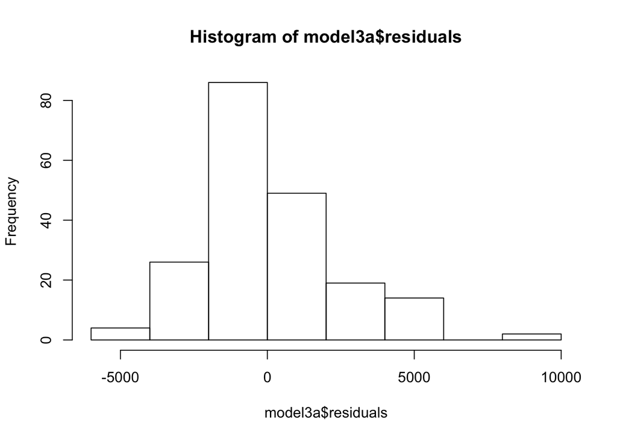

```r
hist(model3a$residuals)
```

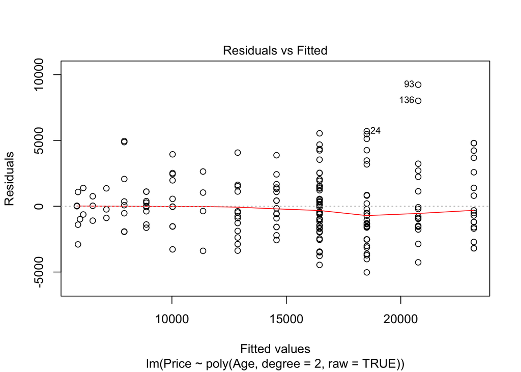

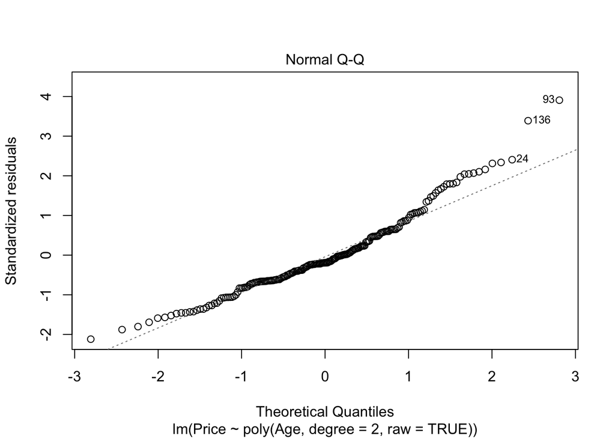

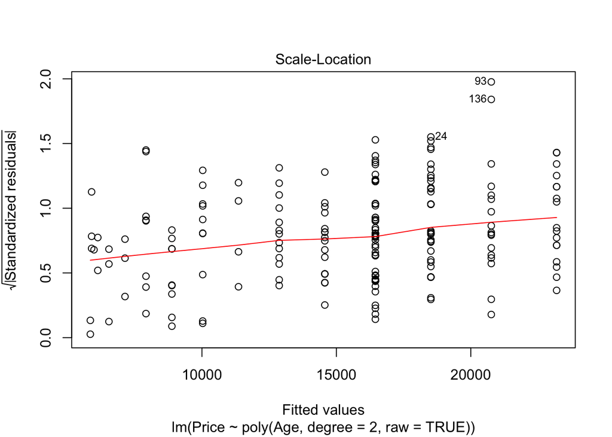

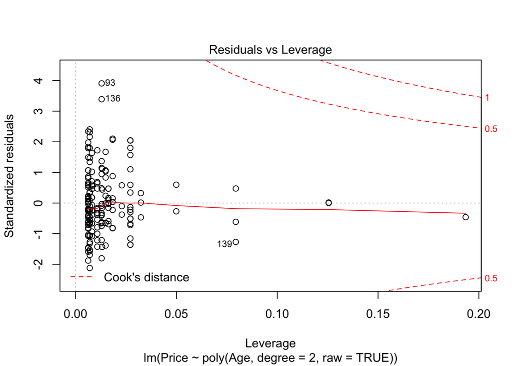

```r
plot(model3a)
```

Residual Analysis:

Based on the fitted values vs residuals plot seem to be distributed evenly around the horizontal reference line. There is a little bit of fanning that occurs as the fitted values increase, but it seems realitively linear. Because the residuals are seemingly equally distributed around the reference line this also implies that there is zero mean. Residuals seem to be scattered around 0 implying constant variance of the residuals. There is a little right-skew in the frequency of the residuals as seen in the histogram, however this is relatively tame. The tails of the QQ plot deviate a little from the diagonal reference line but are generally independent and seem normally distributed. I would have checked normality using sapply() however the output would have been too massive to really check.

*Part B*

Null Hypothesis: H<sub>0</sub>: β<sub>Age</sub> = β<sub>Age^2</sub> =0

Alternative Hypothesis: H<sub>a</sub>: β<sub>Age</sub> + β<sub>Age^2</sub>≠0

```r
#Perform a hypothesis test to determine if this model is significant. List your hypotheses, p-value, and conclusion.

anova455(model3a)
```

|  | Df | Sum Sq | Mean Sq | F value | P(>F) |
| --- | --- | --- | --- | --- | --- |
| Model | 2 | 4351714062 | 2175857031 | 384.0371 | 0 |
| Error | 197 | 1116152269 | 5665748 | NA | NA |
| Total | 199 | 5467866330 | NA | NA | NA |

Using anova455() we can determine that the model created in part A is significant. This is because our p-value is < 2.2e-16 which is effectively 0. Beacuse of this we can reject the null hypothesis.

*Part C*

```r
#You are looking at a 3-year-old car of your model and want to find an interval that is likely to contain its Price using your quadratic model. Construct an interval predict the value of this car, and include an interpretive sentence in context.

newx = data.frame(Age=3)
predict.lm(model3a, newx, interval = "prediction", level=0.95)
```

```
##        fit      lwr      upr
## 1 16451.17 11742.39 21159.96
```

*Part D*

```r
#Does the quadratic model allow for some Age where a car has a zero or negative predicted price? Justify your answer using a calculation or graph.

plot(Price~Age,main="Quadratic Model",data=MyCars)
curve(b0.model3a+b1.model3a*x+b2.model3a*x^2,add=TRUE)
```

[output not shown]

*Part E*

```r
#What happens in the quadratic model for cars that are very old? Can you think of a plausible “real world” explanation for this- or is it a flaw of the quadratic model?

OldCars = MyCars[MyCars$Age>11,]
count(OldCars)
```

| Id | Price | Year | Mileage | City | State | Vin | Make | Model | Age | freq |
| --- | --- | --- | --- | --- | --- | --- | --- | --- | --- | --- |
| 371182 | 4999 | 2002 | 107950 | West Palm Beach | FL | 1HGCG56662A024402 | Honda | Accord | 15 | 1 |
| 376415 | 5888 | 2003 | 177569 | Ventura | CA | JHMCM56783C073637 | Honda | Accord | 14 | 1 |
| 381308 | 7515 | 2005 | 87079 | Cleveland Heights | OH | 1HGCM56845A189850 | Honda | Accord | 12 | 1 |
| 381865 | 5500 | 2005 | 163288 | Longmont | CO | 1HGCM56475A067996 | Honda | Accord | 12 | 1 |
| 766843 | 6981 | 2004 | 99167 | Greensboro | NC | 1HGCM563X4A102228 | Honda | Accord | 13 | 1 |
| 769364 | 4495 | 2004 | 141014 | Houston | TX | 3HGCM56324G710004 | Honda | Accord | 13 | 1 |
| 779685 | 5850 | 2003 | 88000 | Norcross | GA | 3HGCM56353G710044 | Honda | Accord | 14 | 1 |
| 794557 | 2998 | 2004 | 227001 | Marietta | GA | 1HGCM564X4A159036 | Honda | Accord | 13 | 1 |

*Part F*

```r
#Would the fit improve significantly if you also included a cubic term? Does expanding your polynomial model to use a quartic term make significant improvements? Justify your answer.
```

Before I do any modeling, I need to make sure adding these terms doesn’t result in any overfitting of the model.

```r
#Rename model3a so it is consistent
model3fQuadratic = model3a

#Make model3fCubic and model3fQuartic
model3fCubic=lm(Price~poly(Age,degree=3, raw=TRUE), data=MyCars)

model3fQuartic=lm(Price~poly(Age,degree=4, raw=TRUE), data=MyCars)
```

```r
#Scatter plot for model3fQuadratic
summary(model3fQuadratic)
```

```
##
## Call:
## lm(formula = Price ~ poly(Age, degree = 2, raw = TRUE), data = MyCars)
##
## Residuals:
##     Min      1Q  Median      3Q     Max
## -5027.1 -1530.7  -456.2  1333.8  9237.6
##
## Coefficients:
##                                    Estimate Std. Error t value Pr(>|t|)
## (Intercept)                        23193.01     392.35  59.113  < 2e-16
## poly(Age, degree = 2, raw = TRUE)1 -2522.29     165.08 -15.280  < 2e-16
## poly(Age, degree = 2, raw = TRUE)2    91.67      12.95   7.078 2.51e-11
##
## (Intercept)                        ***
## poly(Age, degree = 2, raw = TRUE)1 ***
## poly(Age, degree = 2, raw = TRUE)2 ***
## ---
## Signif. codes:  0 '***' 0.001 '**' 0.01 '*' 0.05 '.' 0.1 ' ' 1
##
## Residual standard error: 2380 on 197 degrees of freedom
## Multiple R-squared:  0.7959, Adjusted R-squared:  0.7938
## F-statistic:   384 on 2 and 197 DF,  p-value: < 2.2e-16
```

```r
b0.model3fQuadratic = summary(model3fQuadratic)$coefficient[1,1]
b1.model3fQuadratic = summary(model3fQuadratic)$coefficient[2,1]
b2.model3fQuadratic = summary(model3fQuadratic)$coefficient[3,1]

plot(Price~Age,main="Quadratic Model",data=MyCars)
curve(b0.model3fQuadratic+b1.model3fQuadratic*x+b2.model3fQuadratic*x^2,add=TRUE)
```

[output not shown]

```r
#Scatter plot for model3fCubic
summary(model3fCubic)
```

```
##
## Call:
## lm(formula = Price ~ poly(Age, degree = 3, raw = TRUE), data = MyCars)
##
## Residuals:
##     Min      1Q  Median      3Q     Max
## -4930.7 -1497.0  -381.1  1255.3  9156.6
##
## Coefficients:
##                                     Estimate Std. Error t value Pr(>|t|)
## (Intercept)                        23589.150    481.202  49.021  < 2e-16
## poly(Age, degree = 3, raw = TRUE)1 -2914.671    322.529  -9.037  < 2e-16
## poly(Age, degree = 3, raw = TRUE)2   173.156     59.024   2.934  0.00375
## poly(Age, degree = 3, raw = TRUE)3    -4.213      2.978  -1.415  0.15870
##
## (Intercept)                        ***
## poly(Age, degree = 3, raw = TRUE)1 ***
## poly(Age, degree = 3, raw = TRUE)2 **
## poly(Age, degree = 3, raw = TRUE)3
## ---
## Signif. codes:  0 '***' 0.001 '**' 0.01 '*' 0.05 '.' 0.1 ' ' 1
##
## Residual standard error: 2374 on 196 degrees of freedom
## Multiple R-squared:  0.7979, Adjusted R-squared:  0.7948
## F-statistic:   258 on 3 and 196 DF,  p-value: < 2.2e-16
```

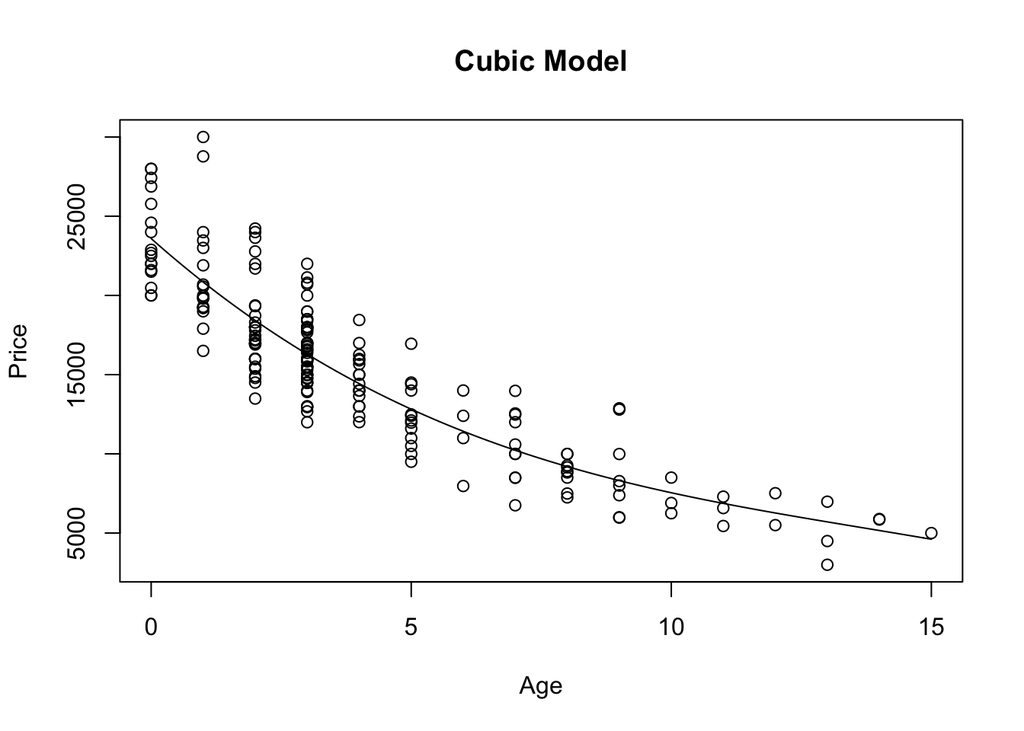

```r
b0.model3fCubic = summary(model3fCubic)$coefficient[1,1]
b1.model3fCubic = summary(model3fCubic)$coefficient[2,1]
b2.model3fCubic = summary(model3fCubic)$coefficient[3,1]
b3.model3fCubic = summary(model3fCubic)$coefficient[4,1]

plot(Price~Age,main="Cubic Model",data=MyCars)
curve(b0.model3fCubic+b1.model3fCubic*x+b2.model3fCubic*x^2+b3.model3fCubic*x^3,add=TRUE)
```

```r
#Scatter plot for model3fQuartic
summary(model3fQuartic)
```

```
##
## Call:
## lm(formula = Price ~ poly(Age, degree = 4, raw = TRUE), data = MyCars)
##
## Residuals:
##     Min      1Q  Median      3Q     Max
## -4879.2 -1470.2  -369.8  1399.3  9186.9
##
## Coefficients:
##                                      Estimate Std. Error t value Pr(>|t|)
## (Intercept)                        23674.2326   525.5191  45.049  < 2e-16
## poly(Age, degree = 4, raw = TRUE)1 -3093.1267   544.4188  -5.682  4.8e-08
## poly(Age, degree = 4, raw = TRUE)2   244.8000   185.5575   1.319    0.189
## poly(Age, degree = 4, raw = TRUE)3   -13.1738    22.1981  -0.593    0.554
## poly(Age, degree = 4, raw = TRUE)4     0.3391     0.8326   0.407    0.684
##
## (Intercept)                        ***
## poly(Age, degree = 4, raw = TRUE)1 ***
## poly(Age, degree = 4, raw = TRUE)2
## poly(Age, degree = 4, raw = TRUE)3
## poly(Age, degree = 4, raw = TRUE)4
## ---
## Signif. codes:  0 '***' 0.001 '**' 0.01 '*' 0.05 '.' 0.1 ' ' 1
##
## Residual standard error: 2379 on 195 degrees of freedom
## Multiple R-squared:  0.7981, Adjusted R-squared:  0.794
## F-statistic: 192.7 on 4 and 195 DF,  p-value: < 2.2e-16
```

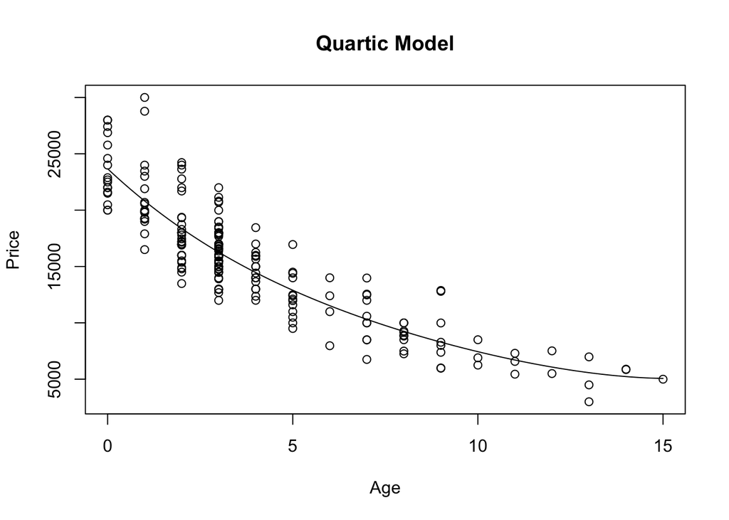

```r
b0.model3fQuartic = summary(model3fQuartic)$coefficient[1,1]
b1.model3fQuartic = summary(model3fQuartic)$coefficient[2,1]
b2.model3fQuartic = summary(model3fQuartic)$coefficient[3,1]
b3.model3fQuartic = summary(model3fQuartic)$coefficient[4,1]
b4.model3fQuartic = summary(model3fQuartic)$coefficient[5,1]

plot(Price~Age,main="Quartic Model",data=MyCars)
curve(b0.model3fQuartic+b1.model3fQuartic*x+b2.model3fQuartic*x^2+b3.model3fQuartic*x^3 +b4.model3fQuartic*x^4,add=TRUE)
```

Although all of the models appear to fit the data well, once we look at the summary outputs we can see which predictors are and aren’t significant in the model. Looking at the sumamry output for model3fQuadratic, all the predictors are highly significant. Looking at the summary output for model3fCubic, 3 of the 4 predictors are significant but the cubic term isn’t (p = 0.15870). Looking at the summary output of model3fQuartic, only two of the predictors were significant. The significant predictors only the constant term and the linear term. The quadratic, cubic, and quartic terms were all insignificant with p values of (p = 0.189, 0.554, and 0.684) respectively. Becuase the cubic and quartic models had insignificant predictors, this suggests that both of these models overfit the data, and are unnecessarily complex.

**MODEL #4: Complete second order model**

*Part A*

```r
#Fit a complete second order model for predicting a used car Price based on Age and Mileage and examine the residuals.
#Include interaction term

model4a=lm(Price~Age+Mileage+I(Age^2)+I(Mileage^2)+I(Age*Mileage),data=MyCars)
summary(model4a)
```

```
##
## Call:
## lm(formula = Price ~ Age + Mileage + I(Age^2) + I(Mileage^2) +
##     I(Age * Mileage), data = MyCars)
##
## Residuals:
##    Min     1Q Median     3Q    Max
##  -4826  -1383   -360   1236   8168
##
## Coefficients:
##                    Estimate Std. Error t value Pr(>|t|)
## (Intercept)       2.357e+04  3.970e+02  59.365  < 2e-16 ***
## Age              -1.779e+03  2.311e+02  -7.699 6.83e-13 ***
## Mileage          -6.264e-02  1.641e-02  -3.817 0.000181 ***
## I(Age^2)          5.194e+01  2.696e+01   1.926 0.055523 .
## I(Mileage^2)      8.462e-08  1.946e-07   0.435 0.664243
## I(Age * Mileage)  1.990e-03  4.291e-03   0.464 0.643302
## ---
## Signif. codes:  0 '***' 0.001 '**' 0.01 '*' 0.05 '.' 0.1 ' ' 1
##
## Residual standard error: 2259 on 194 degrees of freedom
## Multiple R-squared:  0.819,  Adjusted R-squared:  0.8143
## F-statistic: 175.6 on 5 and 194 DF,  p-value: < 2.2e-16
```

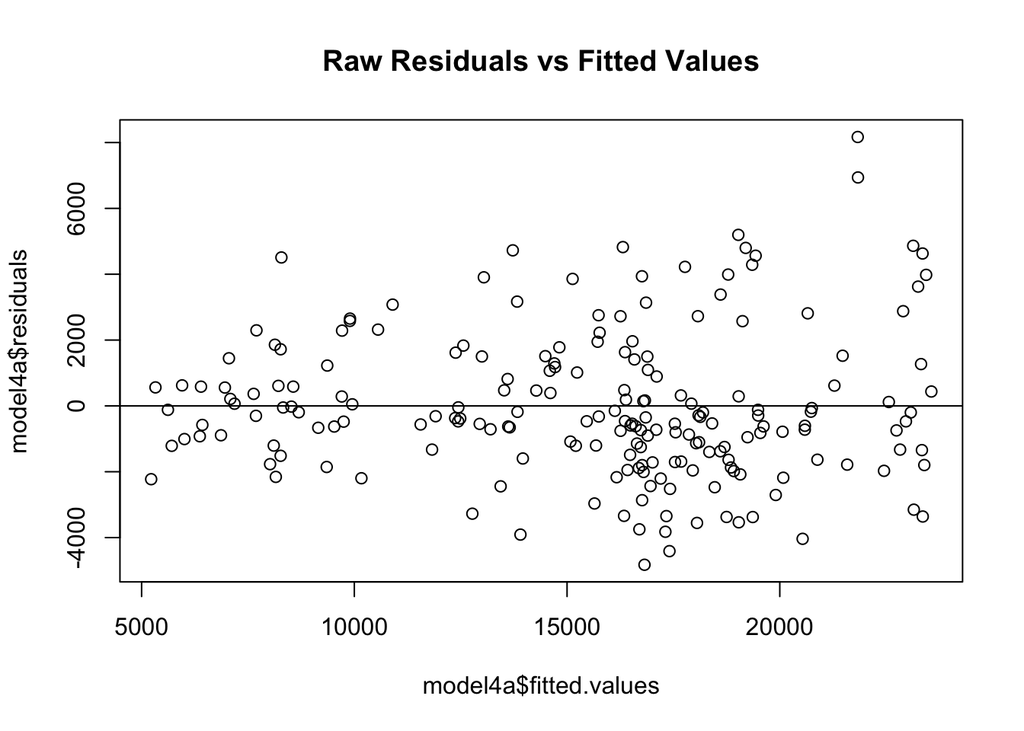

```r
plot(model4a$residuals~model4a$fitted.values, main="Raw Residuals vs Fitted Values", data=MyCars)
abline(0,0)
```

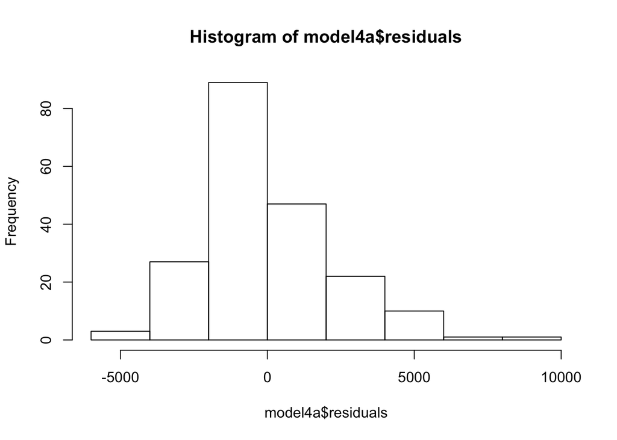

```r
hist(model4a$residuals)
```

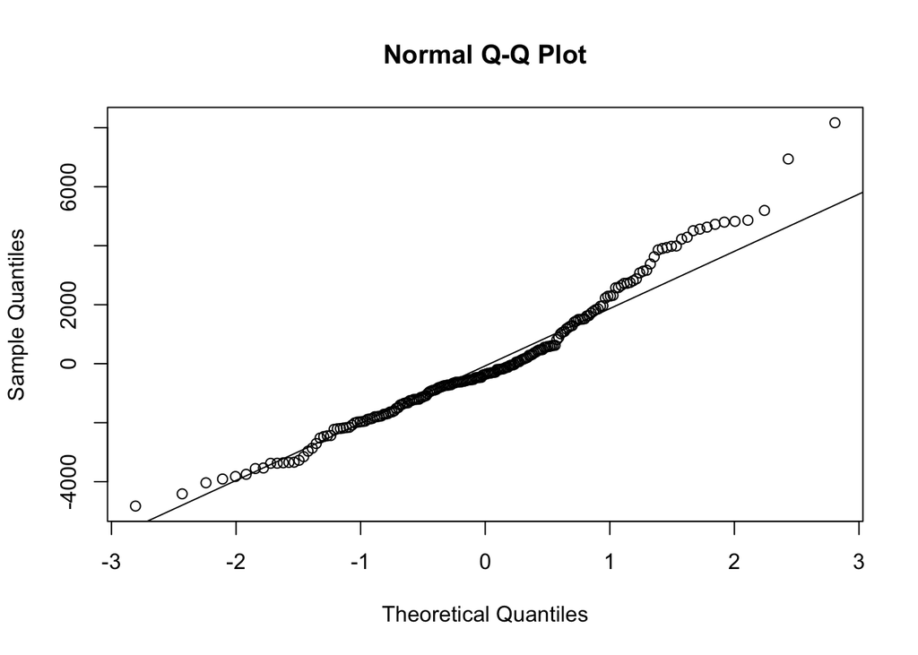

```r
qqnorm(model4a$residuals)
qqline(model4a$residuals)
```

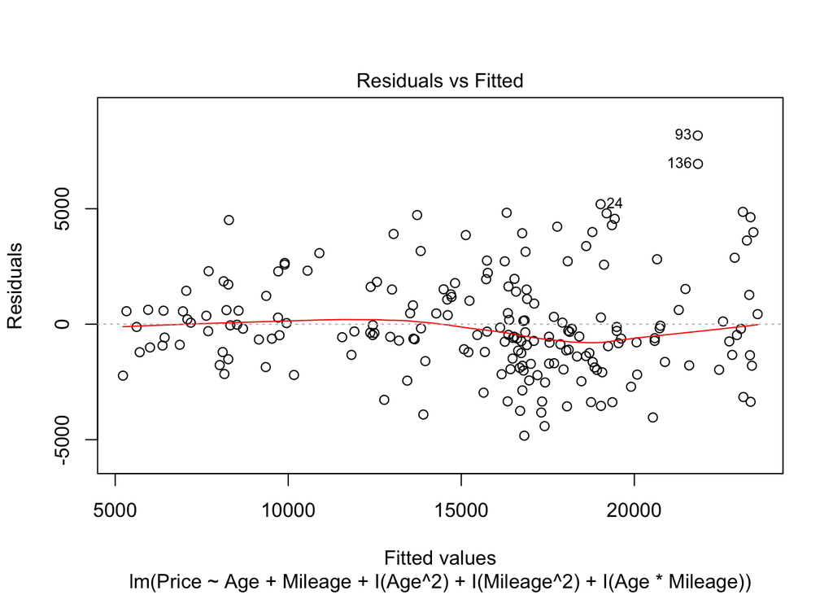

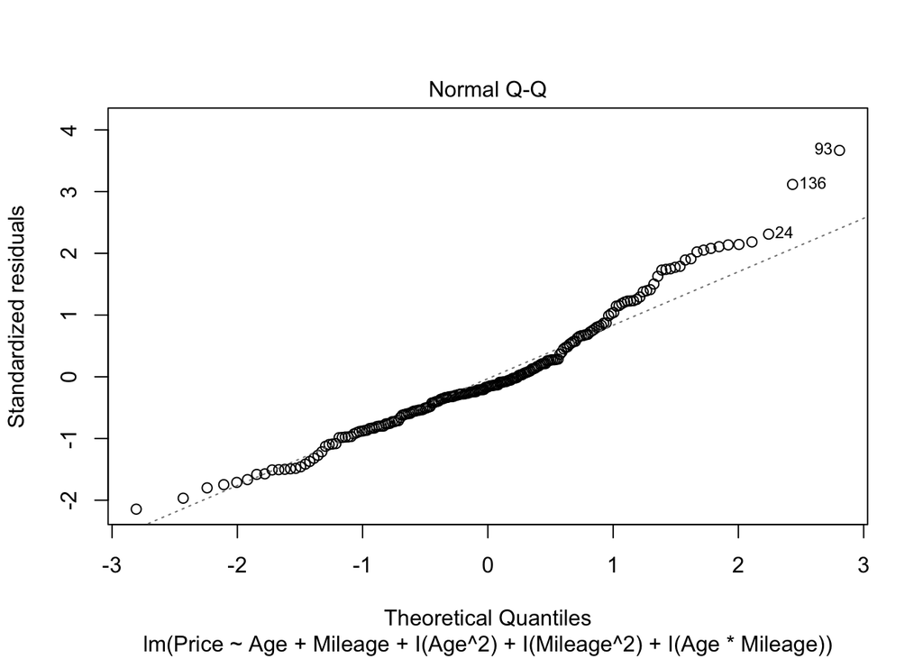

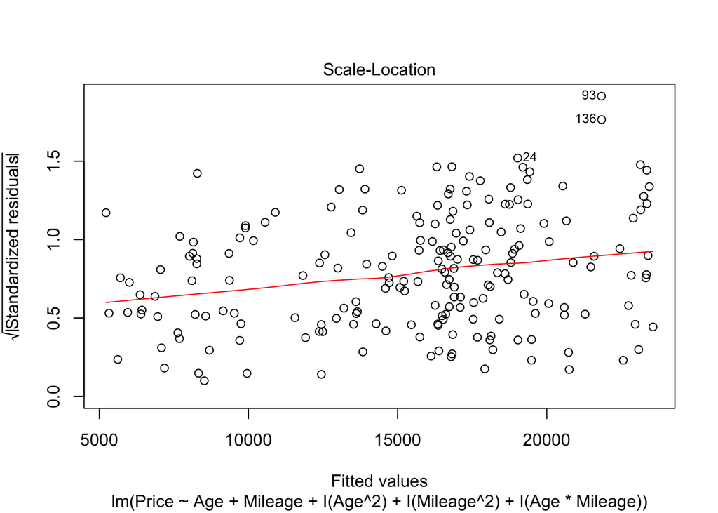

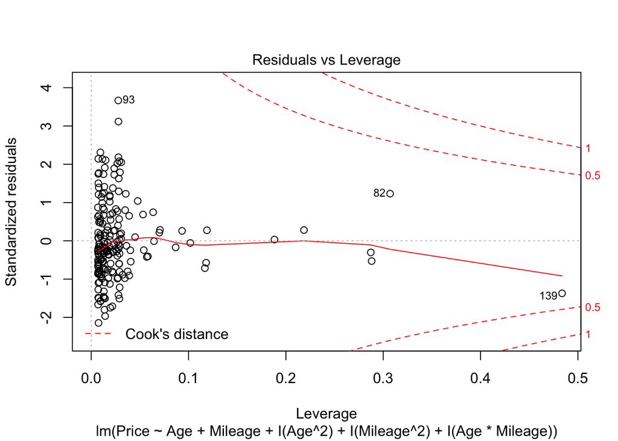

```r
plot(model4a)
```

Residual Analysis:

Based on the fitted values vs residuals plot seem to be distributed evenly around the horizontal reference line. There is some fanning of the residuals as the fitted values increase but overall it looks decently linear. Because the residuals are seemingly equally distributed around the reference line this also implies that there is zero mean and there is constant variance. There is a little right-skew, although less than MODEL 3, in the frequency of the residuals as seen in the histogram, however this is relatively tame seeing as few data sets fit the normal curve perfectly. The tails of the QQ plot deviate a little from the diagonal reference line but are generally independent and seem normally distributed. The right tail deviates more than the left one, and is due to the right skew in the data. I would have checked normality using sapply() however the output would have been too massive to really check.

*Part B*

Null Hypothesis: H<sub>0</sub>: β<sub>Age</sub> = β<sub>Age^2</sub> = β<sub>Mileage</sub> = β<sub>Mileage^2</sub> = β<sub>Age*Mileage</sub>=0

Alternative Hypothesis: H<sub>a</sub>: β<sub>Age</sub> + β<sub>Age^2</sub> +β<sub>Mileage</sub> + β<sub>Mileage^2</sub> + β<sub>Age*Mileage</sub>≠0

```r
anova455(model4a)
```

|  | Df | Sum Sq | Mean Sq | F value | P(>F) |
| --- | --- | --- | --- | --- | --- |
| Model | 5 | 4478150373 | 895630075 | 175.5577 | 0 |
| Error | 194 | 989715957 | 5101629 | NA | NA |
| Total | 199 | 5467866330 | NA | NA | NA |

Using anova455() we can determine that the model created in part A is significant. This is because our p-value is < 2.2e-16 which is effectively 0. Beacuse of this we can reject the null hypothesis. I used anova455() instead of anova() because we want to see if the overall model is significant, not individual predictors.

*Part C*

Null Hypothesis: H<sub>0</sub>: β<sub>Age^2</sub> = β<sub>Mileage^2</sub> = β<sub>Age*Mileage</sub>=0

Alternative Hypothesis: H<sub>a</sub>: β<sub>Age^2</sub> + β<sub>Mileage^2</sub> + β<sub>Age*Mileage</sub>≠0

```r
#Reduced model leaves out predictors you are testing
model4c = lm(Price~Age+Mileage, data=MyCars)
anova(model4c,model4a)
```

|  | Res.Df | RSS | Df | Sum of Sq | F | Pr(>F) |
| --- | --- | --- | --- | --- | --- | --- |
| 1 | 197 | 1215450920 | NA | NA | NA | NA |
| 2 | 194 | 989715957 | 3 | 225734963 | 14.74921 | 1.087301e-08 |

Using anova() to compare the reduced model (model4c) with the original model (model4a) we see that the nested F test tells us that at least one of the predictors we are interested in is significant (p-value = 1.087e-08) and should be included in the model. We should reject the null hypothesis.

*Part D*

Null Hypothesis: H<sub>0</sub>: β<sub>Mileage</sub> = β<sub>Mileage^2</sub> = β<sub>Age*Mileage</sub>=0

Alternative Hypothesis: H<sub>a</sub>: β<sub>Mileage</sub> + β<sub>Mileage^2</sub> + β<sub>Age*Mileage</sub>≠0

```r
model4d = lm(Price~Age + I(Age^2),data=MyCars)
anova(model4d, model4a)
```

|  | Res.Df | RSS | Df | Sum of Sq | F | Pr(>F) |
| --- | --- | --- | --- | --- | --- | --- |
| 1 | 197 | 1116152269 | NA | NA | NA | NA |
| 2 | 194 | 989715957 | 3 | 126436312 | 8.261173 | 3.360103e-05 |

Using anova() to compare the reduced model (model4d) with the original model (model4a) we see that the nested F test tells us that at least one of the predictors we are interested in is significant (p-value = 3.36e-05) and should be included in the model. We should reject the null hypothesis.

**MODEL #5: Categorical predictors**

*Setup*

```r
UsedCars <- read_csv("/Users/reidbrown/Documents/Senior/Spring 2020/STOR 455/Class Example Data/UsedCars.csv")
cars = subset(as.data.frame(table(UsedCars$Model)), Freq>2500)

cars
```

|  | Var1 | Freq |
| --- | --- | --- |
| 29 | 200Limited | 4299 |
| 45 | 3 | 11131 |
| 103 | 5 | 5348 |
| 217 | AcadiaAWD | 3511 |
| 218 | AcadiaFWD | 4080 |
| 230 | Accord | 14946 |
| 249 | Altima2.5 | 15735 |
| 253 | Altima4dr | 2950 |
| 367 | C-ClassC300 | 3307 |
| 412 | CamaroCoupe | 5729 |

[output cut: 76 more lines]

```r
# Do NOT use these models of car for your assignment
# Choose different models that fit the given criteria
#For setup of Model 5 of Homework 4

set.seed(19191)
Escape4WD = sample_n(subset(UsedCars, Model=="Escape4WD"), 200)
EscapeFWD = sample_n(subset(UsedCars, Model=="EscapeFWD"), 200)
EscapeSE = sample_n(subset(UsedCars, Model=="EscapeSE"), 200)

#Combines the rows of the three different dataframes into a new dataframe called Escape
Escape=rbind(Escape4WD, EscapeFWD, EscapeSE)
write.csv(Escape, file="Escape.csv", row.names=FALSE)
```

*Part A*

```r
Escape$Age = 2017-Escape$Year #Create Age variable
model5a = lm(Price~Age+Mileage+Model, data=Escape) #Make Model
summary(model5a)
```

```
##
## Call:
## lm(formula = Price ~ Age + Mileage + Model, data = Escape)
##
## Residuals:
##    Min     1Q Median     3Q    Max
##  -6259  -1497   -374    984  88092
##
## Coefficients:
##                  Estimate Std. Error t value Pr(>|t|)
## (Intercept)     2.371e+04  3.991e+02  59.426  < 2e-16 ***
## Age            -9.292e+02  1.133e+02  -8.198 1.51e-15 ***
## Mileage        -6.019e-02  8.698e-03  -6.921 1.17e-11 ***
## ModelEscapeFWD -2.478e+03  4.214e+02  -5.881 6.82e-09 ***
## ModelEscapeSE  -2.226e+03  4.220e+02  -5.276 1.85e-07 ***
## ---
## Signif. codes:  0 '***' 0.001 '**' 0.01 '*' 0.05 '.' 0.1 ' ' 1
##
## Residual standard error: 4202 on 595 degrees of freedom
## Multiple R-squared:  0.4686, Adjusted R-squared:  0.4651
## F-statistic: 131.2 on 4 and 595 DF,  p-value: < 2.2e-16
```

*Part B*

Null Hypothesis: H<sub>0</sub>: β<sub>Model</sub>=0

Alternative Hypothesis: H<sub>a</sub>: H<sub>0</sub>: β<sub>Model</sub>≠0

```r
#Reduced model leaves out predictors you are interested in
model5b = lm(Price~Age+Mileage, data=Escape)
anova(model5b, model5a)
```

|  | Res.Df | RSS | Df | Sum of Sq | F | Pr(>F) |
| --- | --- | --- | --- | --- | --- | --- |
| 1 | 597 | 11246326369 | NA | NA | NA | NA |
| 2 | 595 | 10506599959 | 2 | 739726411 | 20.94575 | 1.619293e-09 |

Using anova() to compare the reduced model (model5b) with the original model (model5a) we see that the nested F test tells us that Model is significant (p-value = 1.619e-09) and should be included in the model. We should reject the null hypothesis.

*Part C*

```r
#Fit a multiple regression model using Age, Mileage, Model, and the interactions between Age and Model, and Mileage and Model to predict the Price of the car.

model5c = lm(Price~Age+Mileage+Model+Age*Model+Mileage*Model, data = Escape)
model5c
```

```
##
## Call:
## lm(formula = Price ~ Age + Mileage + Model + Age * Model + Mileage *
##     Model, data = Escape)
##
## Coefficients:
##            (Intercept)                     Age                 Mileage
##              2.380e+04              -8.352e+02              -6.750e-02
##         ModelEscapeFWD           ModelEscapeSE      Age:ModelEscapeFWD
##             -2.819e+03              -2.036e+03              -2.575e+02
##      Age:ModelEscapeSE  Mileage:ModelEscapeFWD   Mileage:ModelEscapeSE
##             -1.224e+02               2.133e-02               2.203e-03
```

*Part D*

Null Hypothesis: H<sub>0</sub>: β<sub>Model</sub> = β<sub>(Age*Model)</sub> = β<sub>(Mileage*Model)</sub>=0

Alternative Hypothesis: H<sub>a</sub>: β<sub>Model</sub> + β<sub>(Age*Model)</sub> + β<sub>(Mileage*Model)</sub>≠0

```r
#Perform a hypothesis test to determine the importance of Model terms in the model constructed in part C). List your hypotheses, p-value, and conclusion.

model5d = lm(Price~Age+Mileage, data=Escape)
anova(model5d,model5c)
```

|  | Res.Df | RSS | Df | Sum of Sq | F | Pr(>F) |
| --- | --- | --- | --- | --- | --- | --- |
| 1 | 597 | 11246326369 | NA | NA | NA | NA |
| 2 | 591 | 10482579683 | 6 | 763746687 | 7.176578 | 2.104726e-07 |

Using anova() to compare the reduced model (model5d) with the original model (model5c) we see that the nested F test tells us that Model is significant (p-value = 2.105e-07) and should be included in the model. We should reject the null hypothesis.

*Part E*

The main difference between the model constructed in part A (without interaction terms) and part C (with interaction terms). Without the interaction terms all you can do with a model is change where its y-intercept is and shift it up and down the y axis. With the interaction terms, you can also control the slope of the line predicting our data. We should use the model with the interaction terms since we can better fit our line to our data.